# Neha and Kumar Analysis

Kevin Donovan

December 15, 2020

# Summary Statistics

| **Characteristic** | **TD**, N = 47<sup>1</sup> | **ASD**, N = 48<sup>1</sup> | **FXS**, N = 51<sup>1</sup> | **p-value**<sup>2</sup> |
| --- | --- | --- | --- | --- |
| LV_tot_vol_(cm3) | 15 (12) | 14 (9) | 23 (17) | 0.003 |
| LV_LatIndex | 0.05 (0.12) | 0.04 (0.13) | 0.03 (0.14) | 0.8 |
| log_LV_tot_vol | 2.53 (0.58) | 2.53 (0.51) | 2.95 (0.58) | <0.001 |
| log_LV_LatIndex | -2.55 (1.21) | -2.46 (1.03) | -2.68 (1.34) | 0.8 |
| Unknown | 19 | 18 | 21 |  |
| TCV_(cm3) | 1,102 (88) | 1,120 (114) | 1,132 (80) | 0.3 |
| Age_(years) | 9.00 (2.81) | 10.31 (2.99) | 9.78 (3.18) | 0.11 |
| vinelandii_abcomp_ss | 103 (9) | 64 (12) | 62 (10) | <0.001 |
| Unknown | 1 | 1 | 2 |  |
| vinelandii_comm_ss | 106 (12) | 66 (15) | 64 (11) | <0.001 |
| Unknown | 1 | 1 | 2 |  |
| vinelandii_dls_ss | 101 (11) | 69 (14) | 64 (11) | <0.001 |
| Unknown | 1 | 1 | 2 |  |
| vinelandii_motor_ss | 108 (11) | 86 (14) | 79 (19) | <0.001 |
| Unknown | 8 | 12 | 20 |  |
| dasii_sa_gca_stand | 120 (15) | 72 (26) | 44 (13) | <0.001 |
| Unknown | 15 | 15 | 17 |  |
| dasii_sa_snc_stand | 115 (15) | 73 (27) | 45 (13) | <0.001 |
| Unknown | 19 | 12 | 17 |  |

<sup>*1*</sup> Statistics presented: Mean (SD) <sup>*2*</sup> Statistical tests performed: One-way ANOVA

# Data Exploration

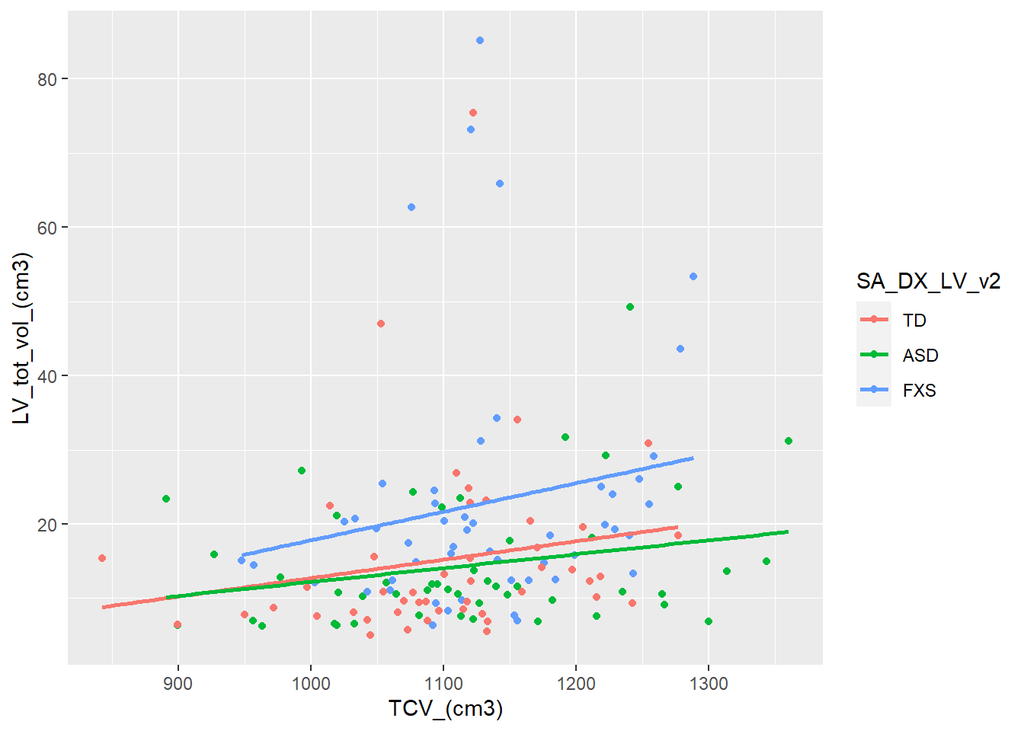

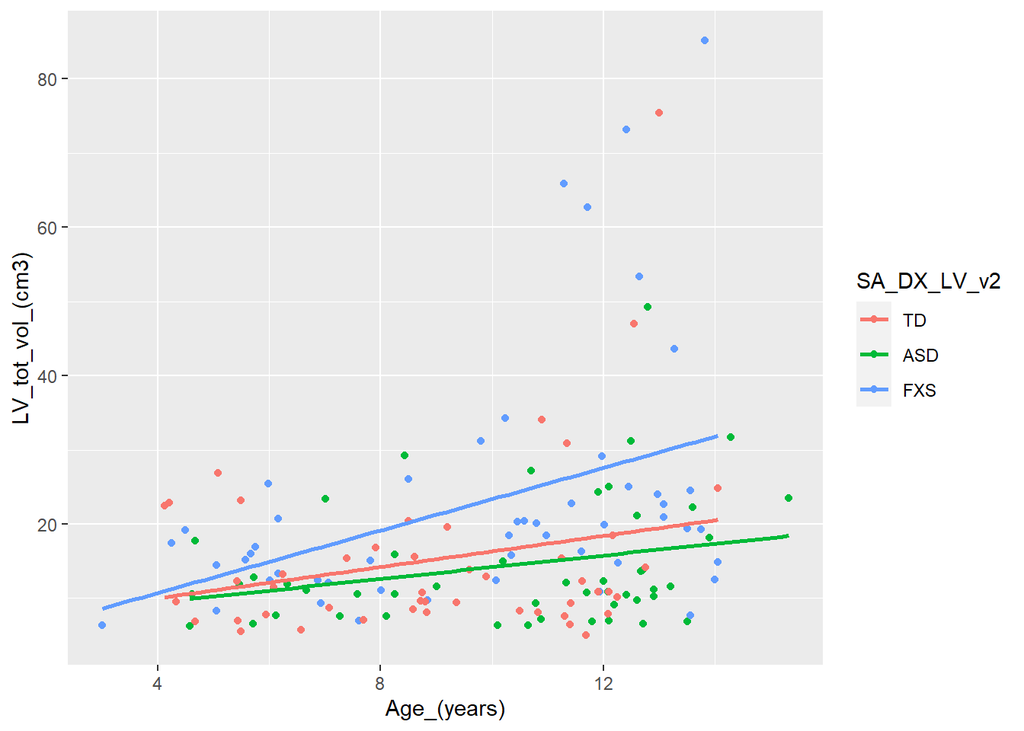

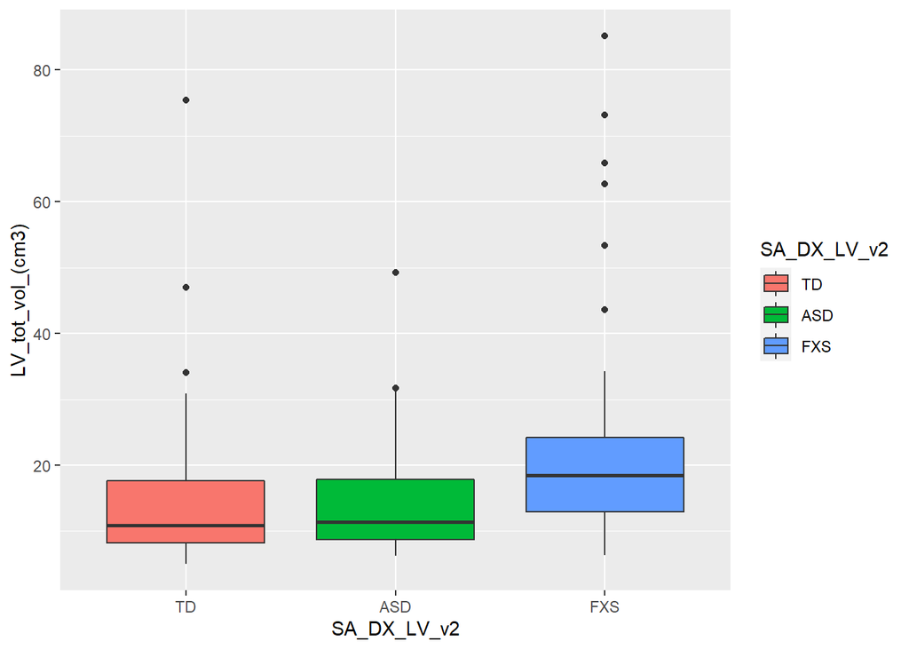

# Analysis Plan

The main objective of this analysis is to estimate the assoications between LV total volume and diagnosis group (TD: Typically Developing, FXS: Fragile X, ASD: Autism) as well as LV total volume and various measures of cognitive ability in school age children This is done using linear regression, while controlling for different sets of additional covariates. The full set of outcome and covariates are the folllwing:

Outcome: LV Total Values

Covariates:

1. **Diagnosis**, TCV, Age, Diagnosis*Age
2. **Vineland Communication standard score**, TCV
3. **Vineland Daily Living standard score**, TCV
4. **Vineland Motor standard score**, TCV
5. **DAS GCA standard score**, TCV
6. **DAS SNC standard score**, TCV

Outcome: LV Lat Index

Covariates:

1. **Diagnosis**, TCV, Age, Diagnosis*Age

For each model, we visually analyzed the residual by fitted value scatterplot as well as the residual QQ plot to assess the goodness of fit of each model to the data/check the assumptions of the linear model. As an way of improving fit while maintaing interpretability, we consider natural log transformations of the outcome for each model. These plots as well as the regression parameter estimates, standard errors, p-values are provided below. We also provide Type III tests for significant main effect of diagnosis when appropriate. All continuous covariates are center to have mean zero to facilitate interpretation of the intercept regression parameter.

# Results

## Diagnostics

### Untransformed Models

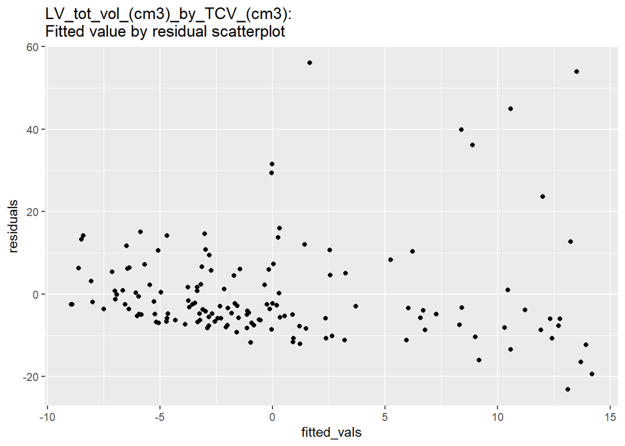

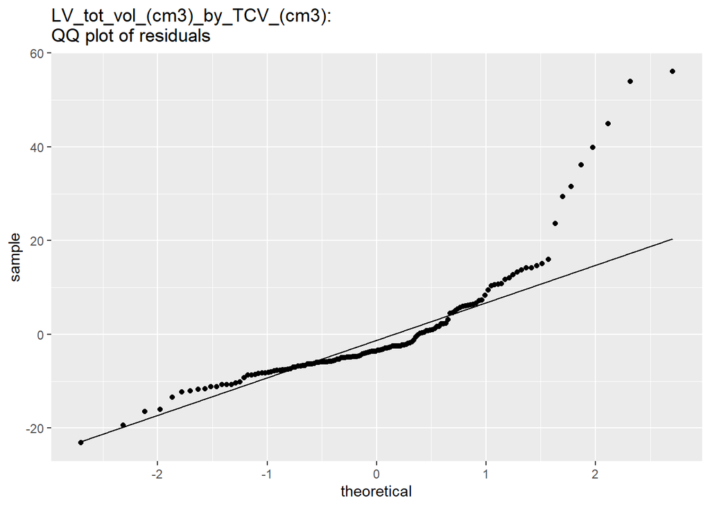

```
##
##
## `LV_tot_vol_(cm3)` ~ `TCV_(cm3)` + `Age_(years)` + SA_DX_LV_v2 +
##     SA_DX_LV_v2 * `TCV_(cm3)` + SA_DX_LV_v2 * `Age_(years)`
##
##
## [[1]]
```

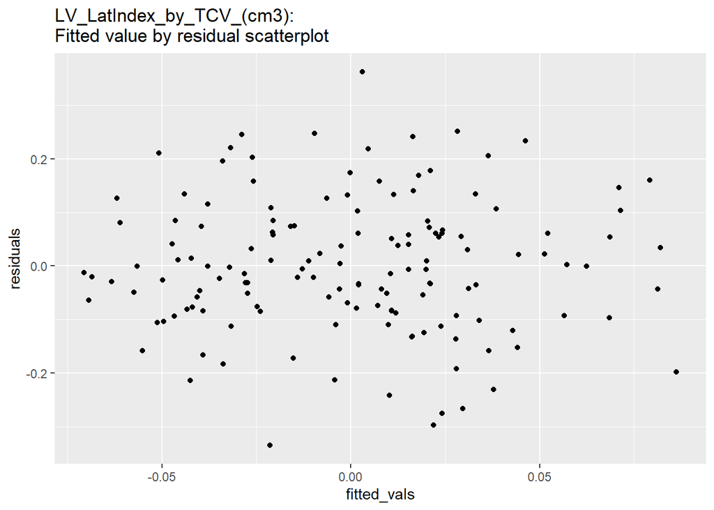

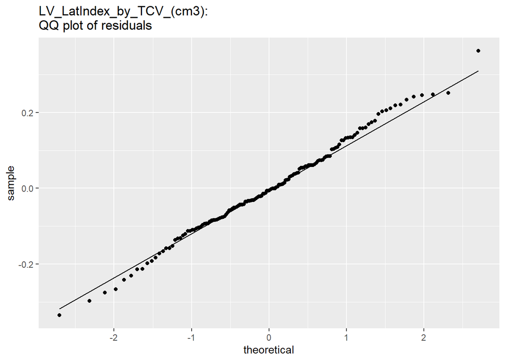

```
##
##
## LV_LatIndex ~ `TCV_(cm3)` + `Age_(years)` + SA_DX_LV_v2 + SA_DX_LV_v2 *
##     `TCV_(cm3)` + SA_DX_LV_v2 * `Age_(years)`
##
##
## [[1]]
```

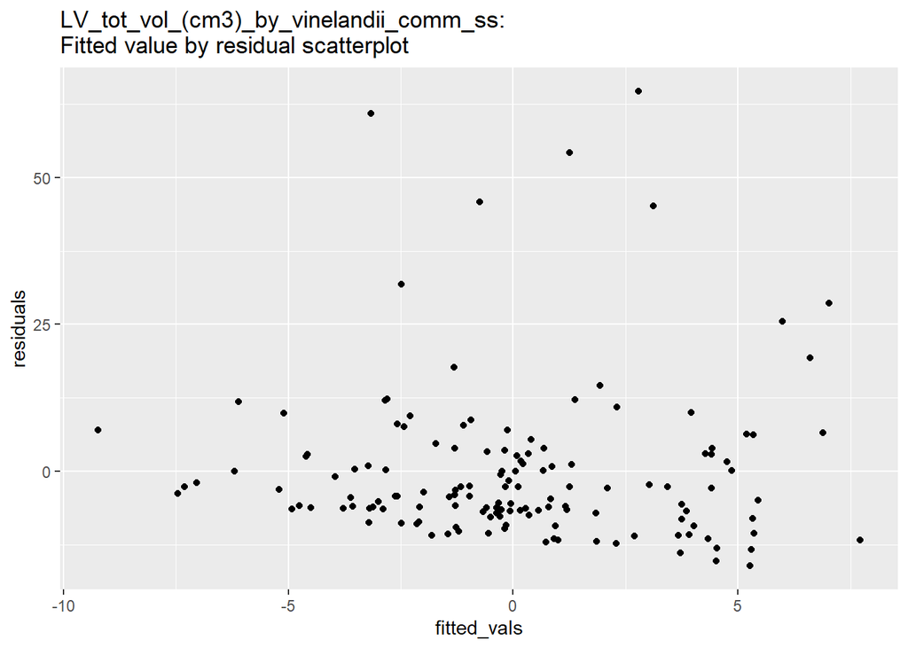

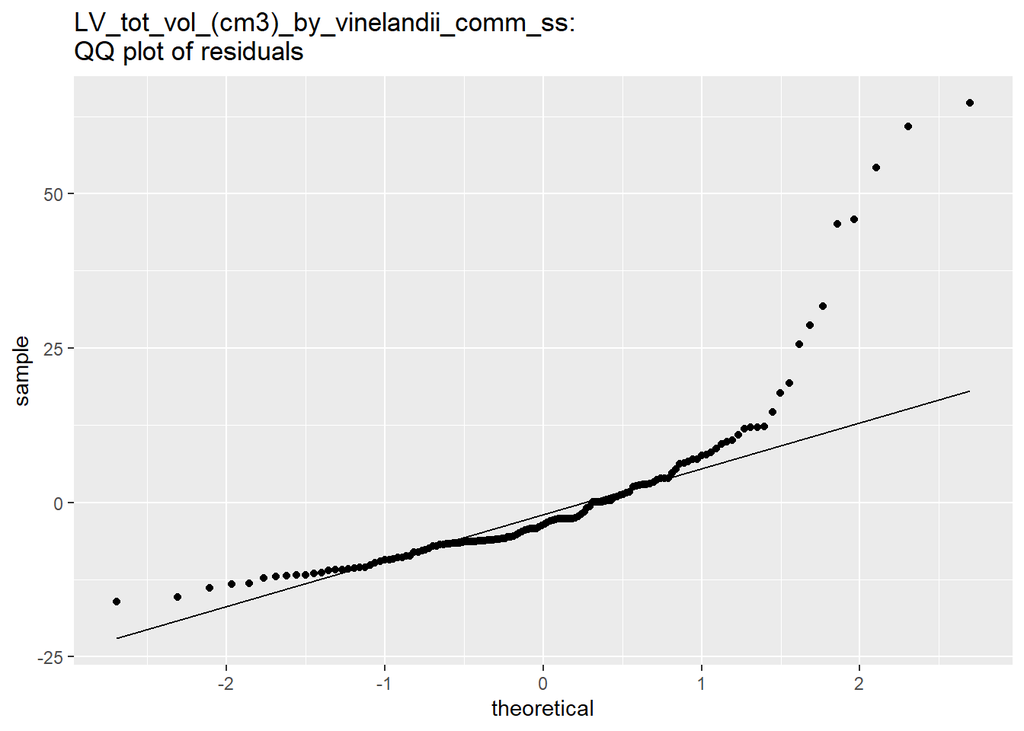

```
##
##
## `LV_tot_vol_(cm3)` ~ vinelandii_comm_ss + `TCV_(cm3)`
##
##
## [[1]]
```

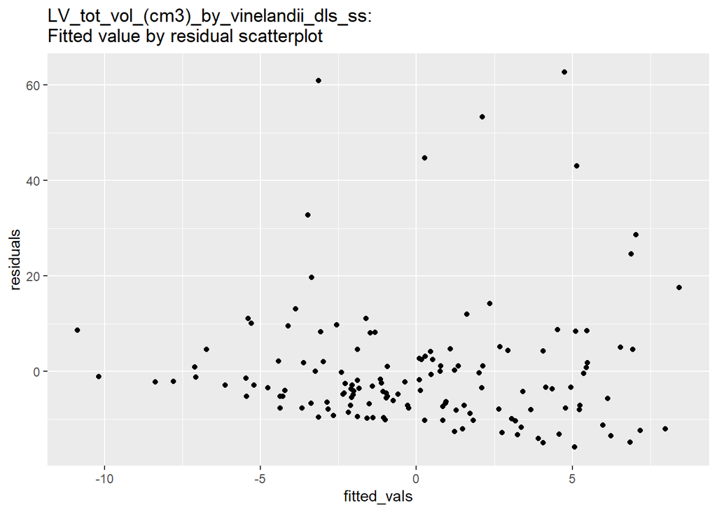

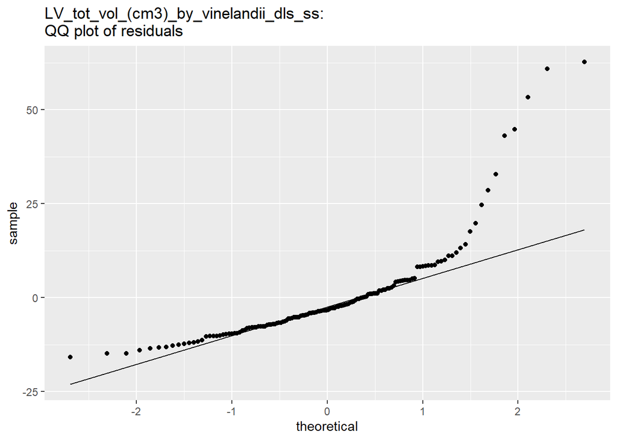

```
##
##
## `LV_tot_vol_(cm3)` ~ vinelandii_dls_ss + `TCV_(cm3)`
##
##
## [[1]]
```

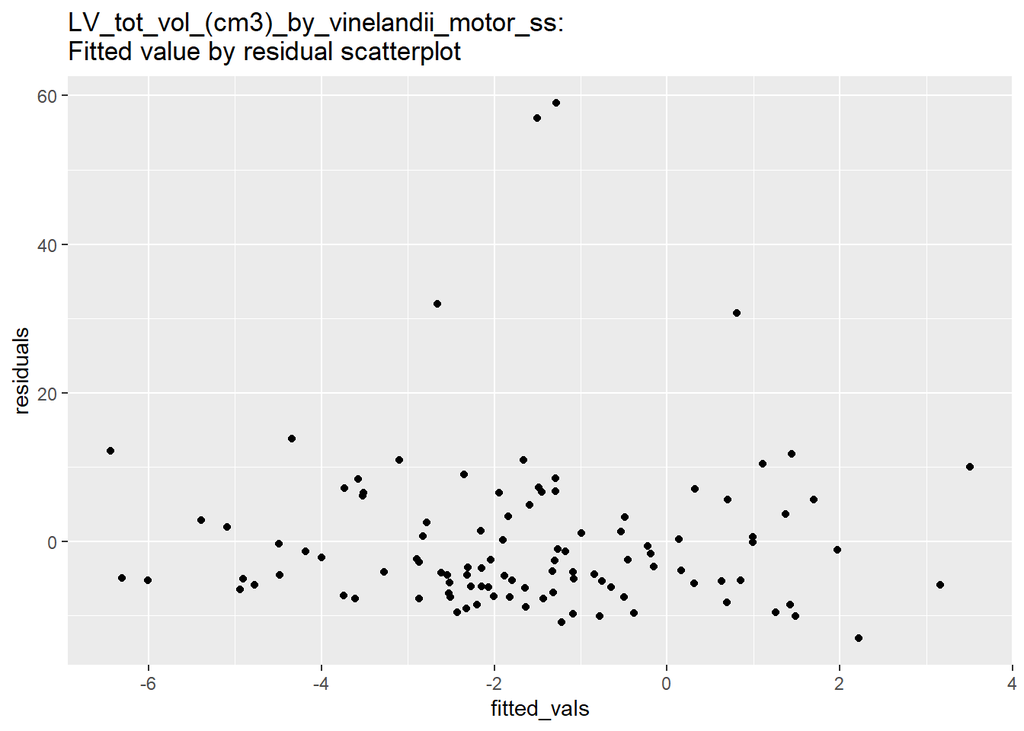

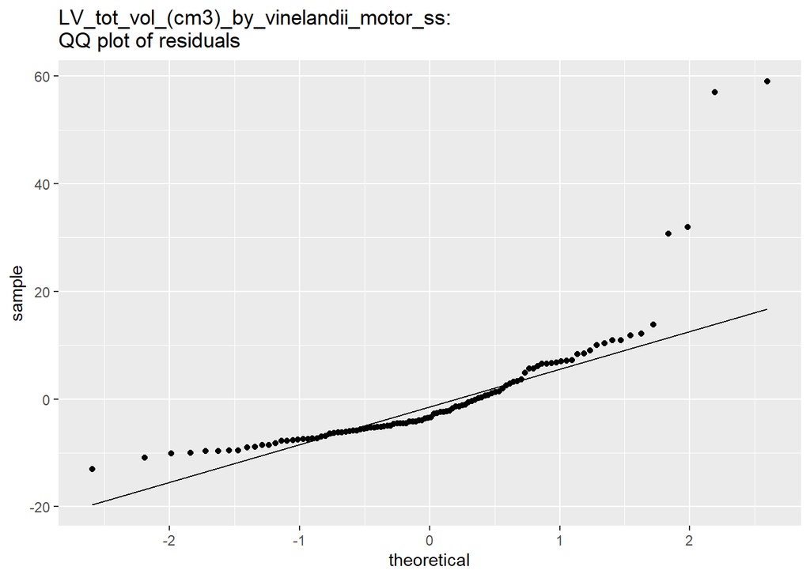

```
##
##
## `LV_tot_vol_(cm3)` ~ vinelandii_motor_ss + `TCV_(cm3)`
##
##
## [[1]]
```

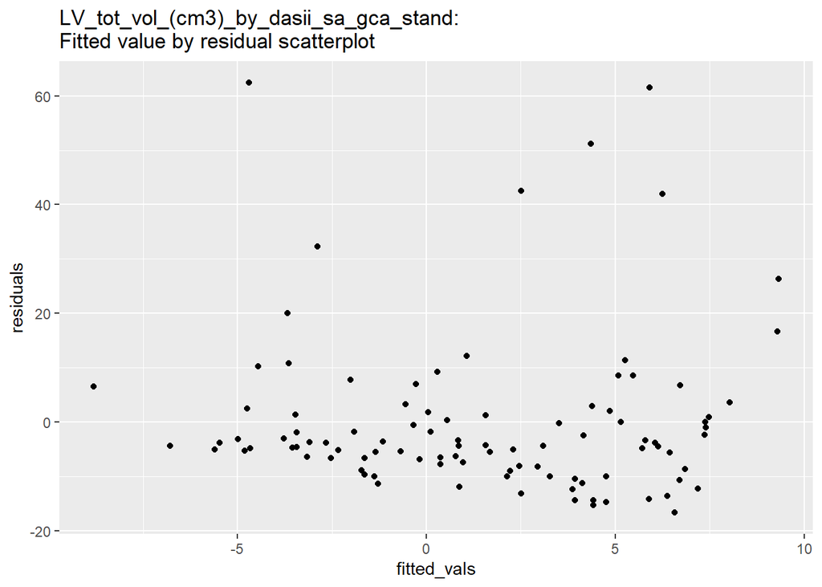

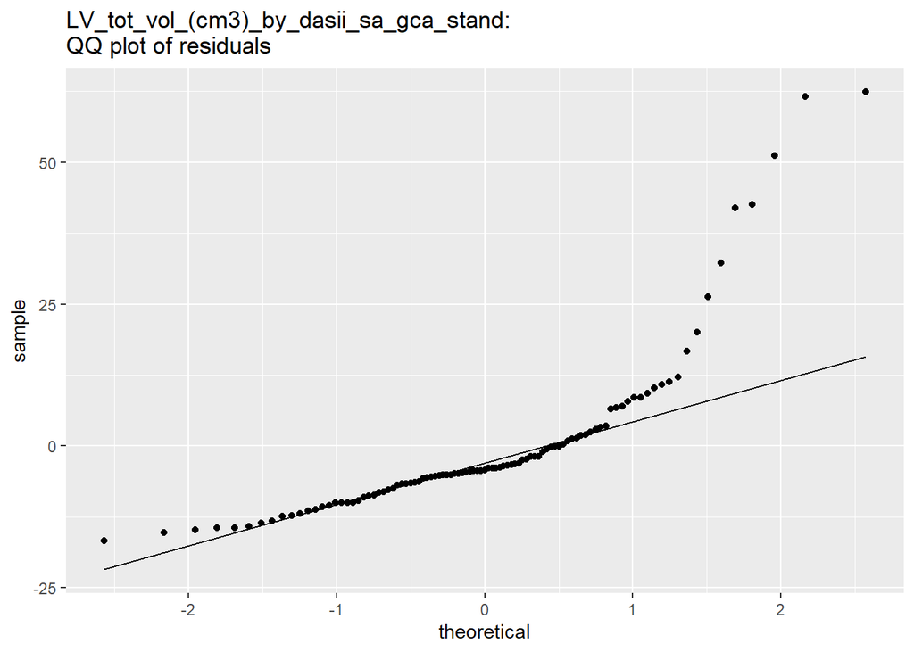

```
##
##
## `LV_tot_vol_(cm3)` ~ dasii_sa_gca_stand + `TCV_(cm3)`
##
##
## [[1]]
```

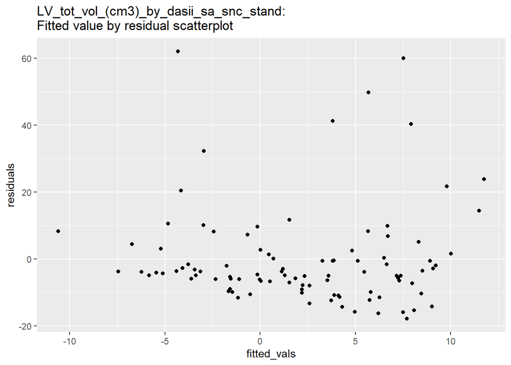

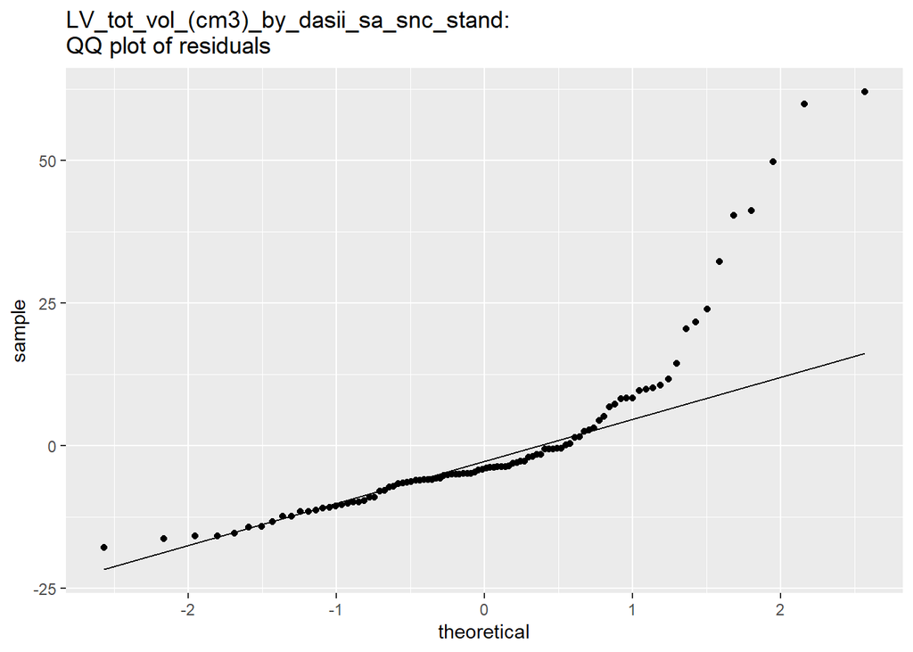

```
##
##
## `LV_tot_vol_(cm3)` ~ dasii_sa_snc_stand + `TCV_(cm3)`
```

### Transformed Models

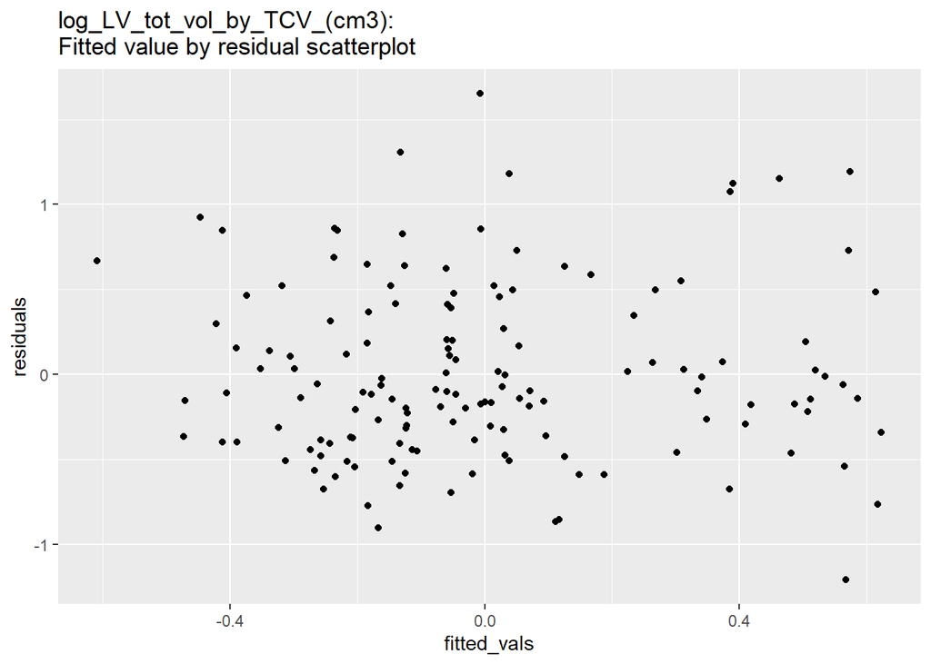

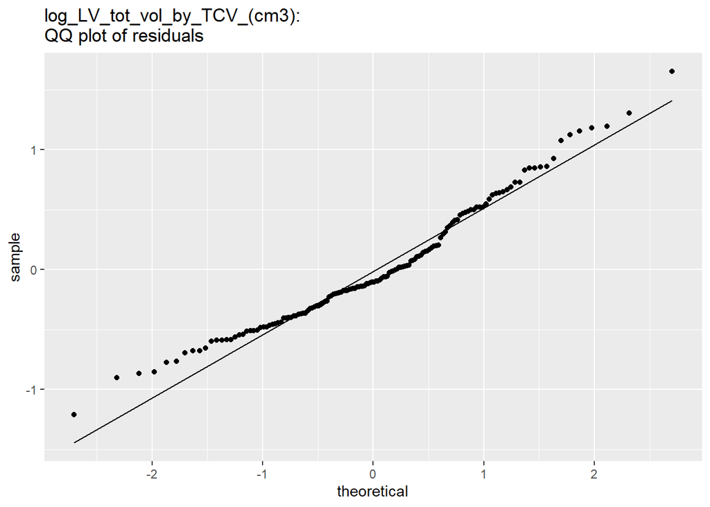

```
##
##
## log_LV_tot_vol ~ `TCV_(cm3)` + `Age_(years)` + SA_DX_LV_v2 +
##     SA_DX_LV_v2 * `TCV_(cm3)` + SA_DX_LV_v2 * `Age_(years)`
##
##
## [[1]]
```

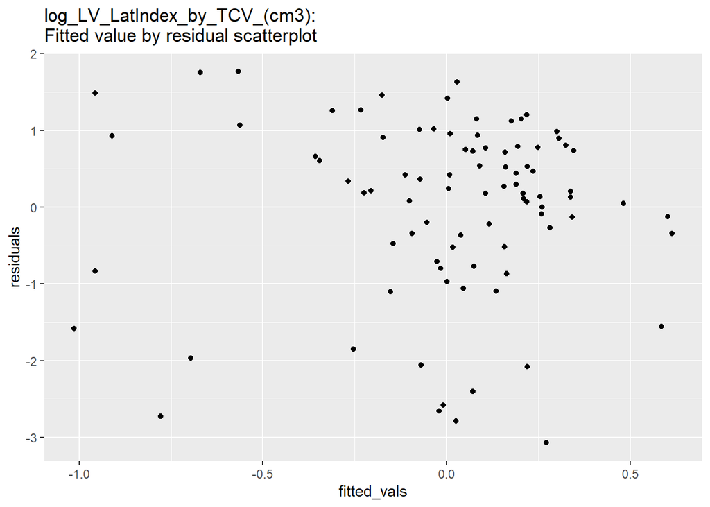

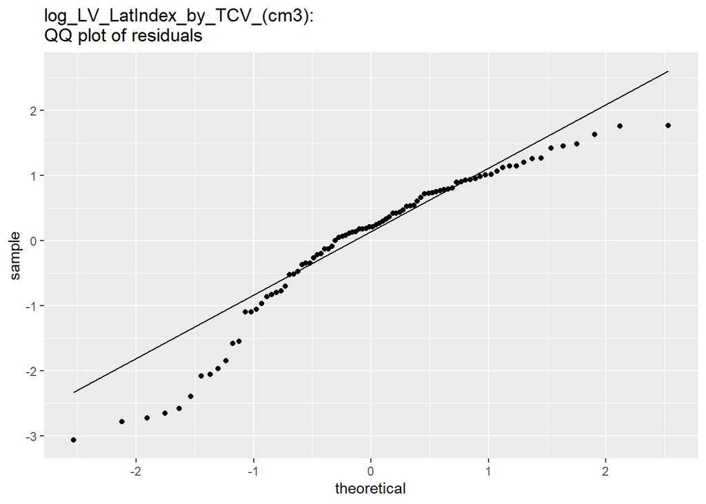

```
##
##
## log_LV_LatIndex ~ `TCV_(cm3)` + `Age_(years)` + SA_DX_LV_v2 +
##     SA_DX_LV_v2 * `TCV_(cm3)` + SA_DX_LV_v2 * `Age_(years)`
##
##
## [[1]]
```

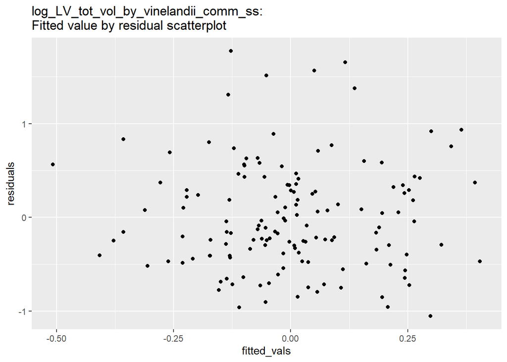

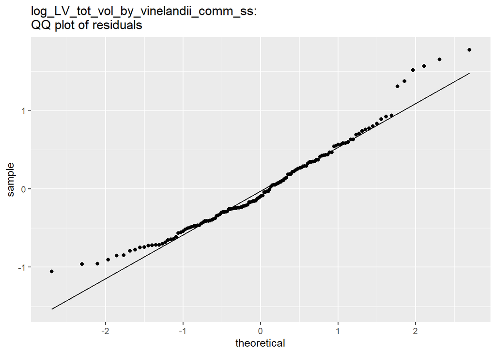

```
##
##
## log_LV_tot_vol ~ vinelandii_comm_ss + `TCV_(cm3)`
##
##
## [[1]]
```

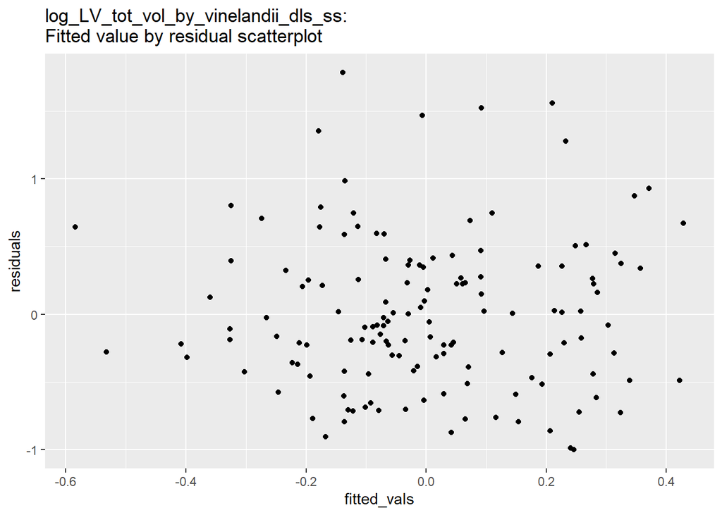

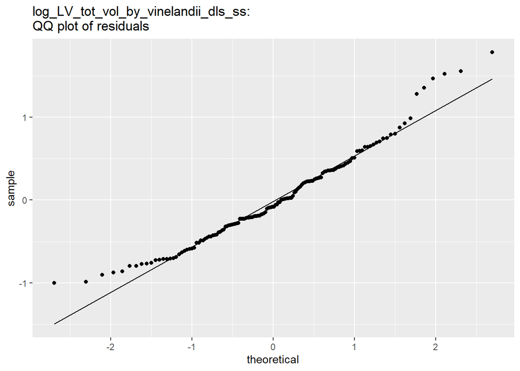

```
##
##
## log_LV_tot_vol ~ vinelandii_dls_ss + `TCV_(cm3)`
##
##
## [[1]]
```

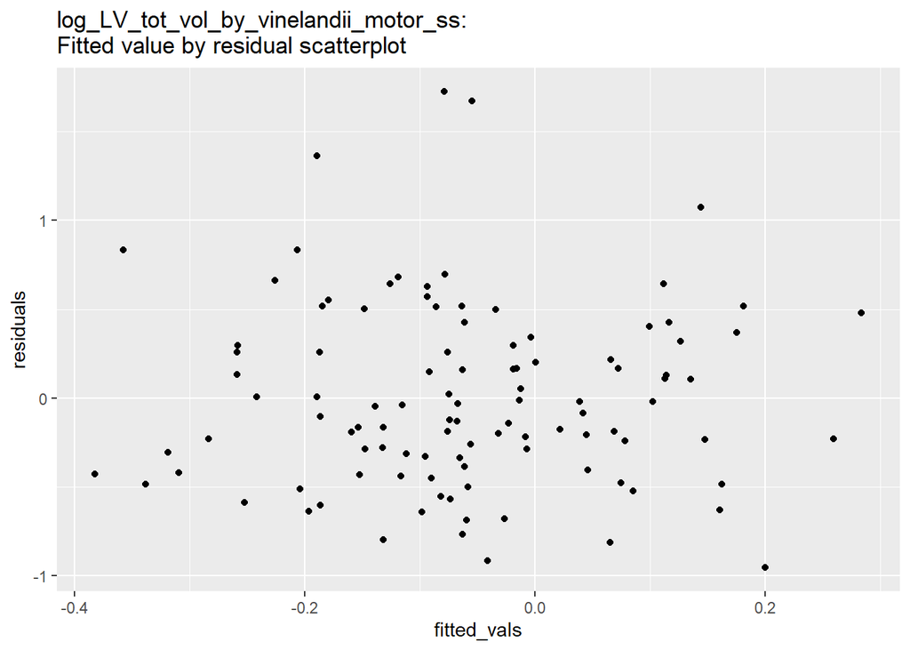

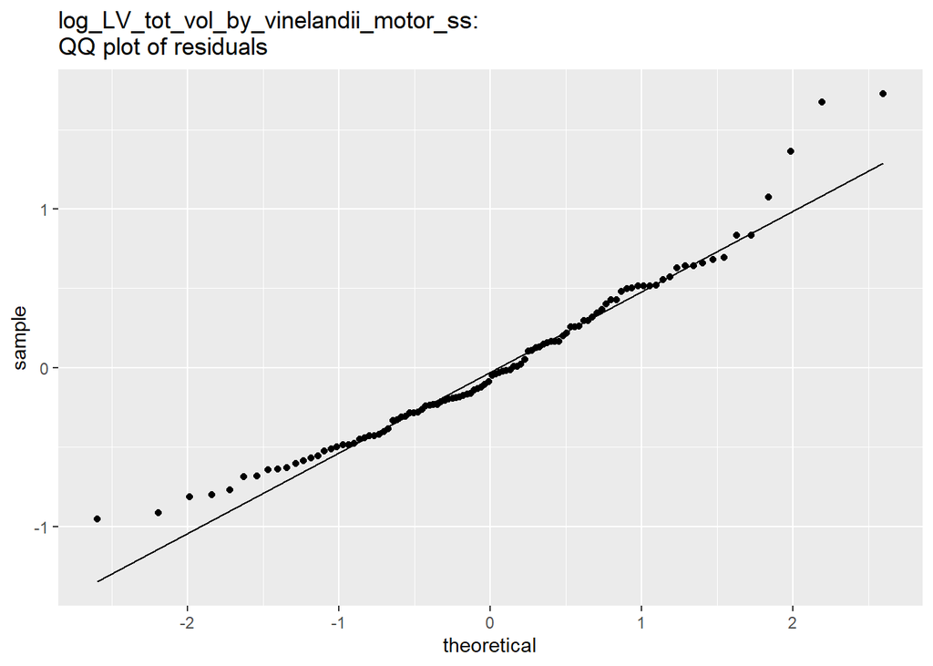

```
##
##
## log_LV_tot_vol ~ vinelandii_motor_ss + `TCV_(cm3)`
##
##
## [[1]]
```

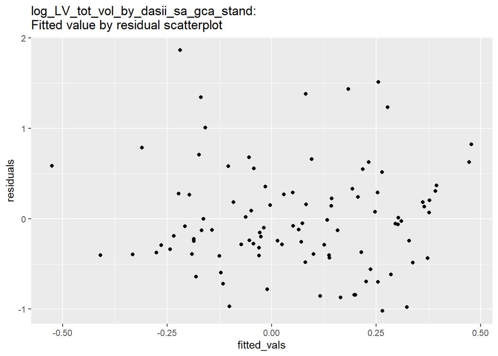

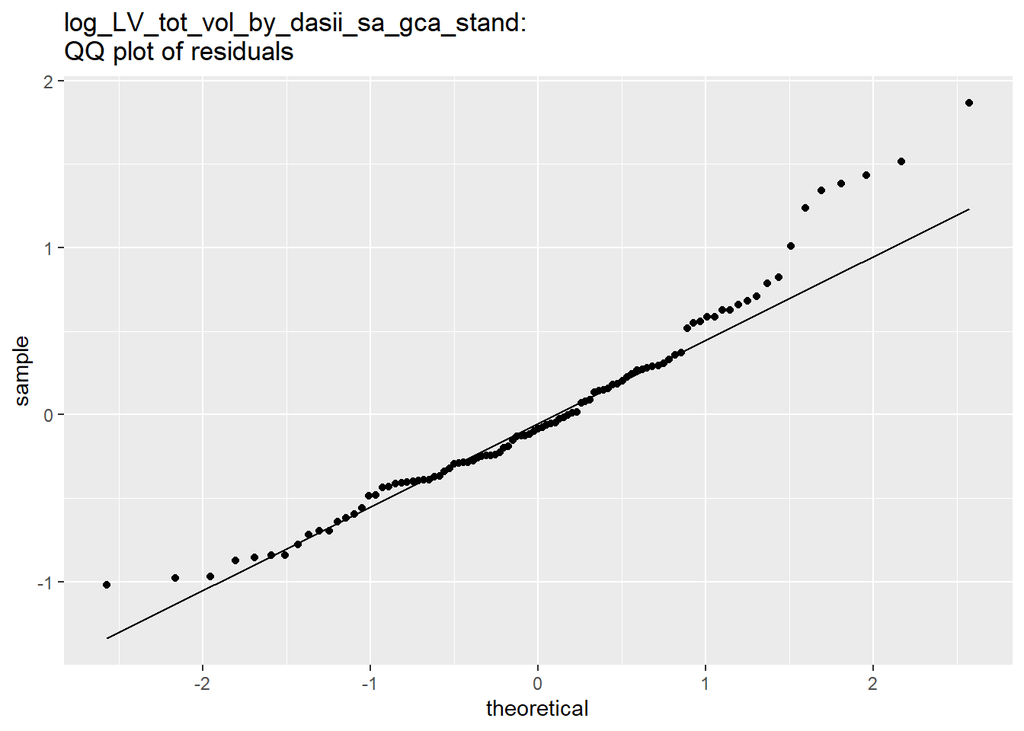

```
##
##
## log_LV_tot_vol ~ dasii_sa_gca_stand + `TCV_(cm3)`
##
##
## [[1]]
```

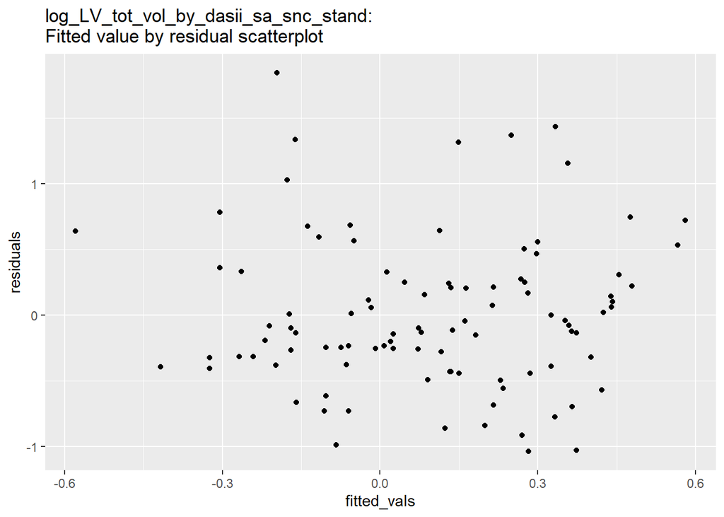

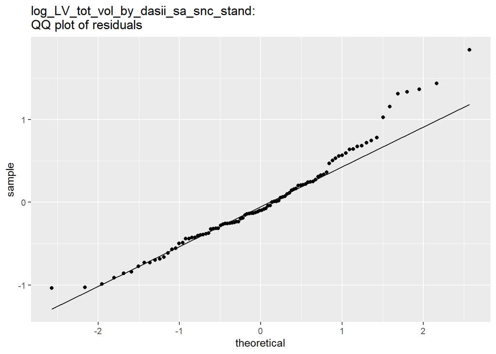

```
##
##
## log_LV_tot_vol ~ dasii_sa_snc_stand + `TCV_(cm3)`
```

## Inference

1. Model name (for organization)
2. Parameter estimates, SEs, etc.
3. Type III tests for main effects

[1] “Model 1”

[1] “Response: log_LV_tot_vol”

[1] “Model: log_LV_tot_vol ~ `TCV_(cm3)` + `Age_(years)` + SA_DX_LV_v2 + SA_DX_LV_v2 * `TCV_(cm3)` + SA_DX_LV_v2 * `Age_(years)`”

| Estimate | Std..Error | t.value | Pr...t.. |
| --- | --- | --- | --- |
| -0.09842 | 0.08039 | -1.22 | 0.2230 |
| 0.00163 | 0.00091 | 1.80 | 0.0747 |
| 0.02577 | 0.02860 | 0.90 | 0.3692 |
| -0.07012 | 0.11217 | -0.63 | 0.5329 |
| 0.35460 | 0.11023 | 3.22 | 0.0016 |
| -0.00082 | 0.00116 | -0.71 | 0.4783 |
| -0.00110 | 0.00137 | -0.80 | 0.4263 |
| 0.00909 | 0.03949 | 0.23 | 0.8183 |
| 0.05024 | 0.03844 | 1.31 | 0.1935 |

| Sum Sq | Df | F value | Pr(>F) |
| --- | --- | --- | --- |
| 0.42 | 1 | 1.50 | 0.22299 |
| 0.91 | 1 | 3.23 | 0.07467 |
| 0.23 | 1 | 0.81 | 0.36921 |
| 4.97 | 2 | 8.83 | 0.00025 |
| 0.21 | 2 | 0.38 | 0.68584 |
| 0.57 | 2 | 1.01 | 0.36608 |
| 38.51 | 137 |  |  |

[1] “Model 2”

[1] “Response: log_LV_LatIndex”

[1] “Model: log_LV_LatIndex ~ `TCV_(cm3)` + `Age_(years)` + SA_DX_LV_v2 + SA_DX_LV_v2 * `TCV_(cm3)` + SA_DX_LV_v2 * `Age_(years)`”

| Estimate | Std..Error | t.value | Pr...t.. |
| --- | --- | --- | --- |
| -0.09164 | 0.2588 | -0.35 | 0.724 |
| 0.00013 | 0.0032 | 0.04 | 0.968 |
| -0.07380 | 0.0890 | -0.83 | 0.409 |
| 0.15691 | 0.3505 | 0.45 | 0.656 |
| -0.08924 | 0.3412 | -0.26 | 0.794 |
| -0.00097 | 0.0039 | -0.25 | 0.803 |
| -0.00126 | 0.0043 | -0.29 | 0.769 |
| 0.09834 | 0.1221 | 0.81 | 0.423 |
| 0.26964 | 0.1260 | 2.14 | 0.035 |

| Sum Sq | Df | F value | Pr(>F) |
| --- | --- | --- | --- |
| 1.8e-01 | 1 | 0.1254 | 0.72 |
| 2.3e-03 | 1 | 0.0016 | 0.97 |
| 9.9e-01 | 1 | 0.6876 | 0.41 |
| 8.4e-01 | 2 | 0.2914 | 0.75 |
| 1.3e-01 | 2 | 0.0467 | 0.95 |
| 6.8e+00 | 2 | 2.3487 | 0.10 |
| 1.1e+02 | 79 |  |  |

[1] “Model 3”

[1] “Response: log_LV_tot_vol”

[1] “Model: log_LV_tot_vol ~ vinelandii_comm_ss + `TCV_(cm3)`”

| Estimate | Std..Error | t.value | Pr...t.. |
| --- | --- | --- | --- |
| 0.0014 | 0.0479 | 0.03 | 0.9760 |
| -0.0032 | 0.0021 | -1.54 | 0.1261 |
| 0.0016 | 0.0005 | 3.10 | 0.0023 |

| Sum Sq | Df | F value | Pr(>F) |
| --- | --- | --- | --- |
| 0.0003 | 1 | 0.00091 | 0.9760 |
| 0.7700 | 1 | 2.36804 | 0.1261 |
| 3.1238 | 1 | 9.60704 | 0.0023 |
| 45.1965 | 139 |  |  |

[1] “Model 4”

[1] “Response: log_LV_tot_vol”

[1] “Model: log_LV_tot_vol ~ vinelandii_dls_ss + `TCV_(cm3)`”

| Estimate | Std..Error | t.value | Pr...t.. |
| --- | --- | --- | --- |
| 0.0014 | 0.0471 | 0.03 | 0.9759 |
| -0.0060 | 0.0023 | -2.59 | 0.0105 |
| 0.0015 | 0.0005 | 3.08 | 0.0025 |

| Sum Sq | Df | F value | Pr(>F) |
| --- | --- | --- | --- |
| 2.9e-04 | 1 | 0.00092 | 0.9759 |
| 2.1e+00 | 1 | 6.72496 | 0.0105 |
| 3.0e+00 | 1 | 9.47127 | 0.0025 |
| 4.4e+01 | 139 |  |  |

[1] “Model 5”

[1] “Response: log_LV_tot_vol”

[1] “Model: log_LV_tot_vol ~ vinelandii_motor_ss + `TCV_(cm3)`”

| Estimate | Std..Error | t.value | Pr...t.. |
| --- | --- | --- | --- |
| -0.0558 | 0.05060 | -1.10 | 0.2726 |
| -0.0013 | 0.00266 | -0.51 | 0.6141 |
| 0.0014 | 0.00054 | 2.68 | 0.0085 |

| Sum Sq | Df | F value | Pr(>F) |
| --- | --- | --- | --- |
| 0.330 | 1 | 1.22 | 0.2726 |
| 0.069 | 1 | 0.26 | 0.6141 |
| 1.951 | 1 | 7.19 | 0.0085 |
| 27.948 | 103 |  |  |

[1] “Model 6”

[1] “Response: log_LV_tot_vol”

[1] “Model: log_LV_tot_vol ~ dasii_sa_gca_stand + `TCV_(cm3)`”

| Estimate | Std..Error | t.value | Pr...t.. |
| --- | --- | --- | --- |
| 0.0420 | 0.05937 | 0.71 | 0.481 |
| -0.0042 | 0.00164 | -2.55 | 0.012 |
| 0.0014 | 0.00059 | 2.45 | 0.016 |

| Sum Sq | Df | F value | Pr(>F) |
| --- | --- | --- | --- |
| 0.17 | 1 | 0.5 | 0.481 |
| 2.25 | 1 | 6.5 | 0.012 |
| 2.07 | 1 | 6.0 | 0.016 |
| 33.12 | 96 |  |  |

[1] “Model 7”

[1] “Response: log_LV_tot_vol”

[1] “Model: log_LV_tot_vol ~ dasii_sa_snc_stand + `TCV_(cm3)`”

| Estimate | Std..Error | t.value | Pr...t.. |
| --- | --- | --- | --- |
| 0.0820 | 0.05888 | 1.4 | 0.1671 |
| -0.0053 | 0.00173 | -3.1 | 0.0029 |
| 0.0015 | 0.00057 | 2.7 | 0.0086 |

| Sum Sq | Df | F value | Pr(>F) |
| --- | --- | --- | --- |
| 0.65 | 1 | 1.9 | 0.1671 |
| 3.15 | 1 | 9.3 | 0.0029 |
| 2.43 | 1 | 7.2 | 0.0086 |
| 32.06 | 95 |  |  |

## Inference - Back Transform

For interpretation, we back transform the log transformation using the exponential function. That is, given the linear model

$log(Y)=\beta_0+\beta_1*X+\epsilon$

$Y=\exp(\beta_0)*\exp(\beta_1X)*\exp(\epsilon)$

this implies for a one unit change in X

$Y=\exp(\beta_1)\exp(\beta_0)*\exp(\beta_1)X*\exp(\epsilon)$

resulting in a percent change in $Y$ given by $\exp(\beta_1)-1$. Using continuity, confidence intervals can be constructed for the regression coefficients also by exponentiating.

[1] “Model 1”

| variable | estimates | lower_ci | upper_ci |
| --- | --- | --- | --- |
| (Intercept) | -0.09373 | -0.22693 | 0.0624 |
| `TCV_(cm3)` | 0.00164 | -0.00016 | 0.0034 |
| `Age_(years)` | 0.02610 | -0.03032 | 0.0858 |
| SA_DX_LV_v2ASD | -0.06772 | -0.25318 | 0.1638 |
| SA_DX_LV_v2FXS | 0.42561 | 0.14640 | 0.7728 |
| `TCV_(cm3)`:SA_DX_LV_v2ASD | -0.00082 | -0.00310 | 0.0015 |
| `TCV_(cm3)`:SA_DX_LV_v2FXS | -0.00109 | -0.00380 | 0.0016 |
| `Age_(years)`:SA_DX_LV_v2ASD | 0.00913 | -0.06667 | 0.0911 |
| `Age_(years)`:SA_DX_LV_v2FXS | 0.05152 | -0.02545 | 0.1346 |

[1] “Model 2”

| variable | estimates | lower_ci | upper_ci |
| --- | --- | --- | --- |
| (Intercept) | -0.08757 | -0.4549 | 0.5273 |
| `TCV_(cm3)` | 0.00013 | -0.0063 | 0.0066 |
| `Age_(years)` | -0.07114 | -0.2219 | 0.1089 |
| SA_DX_LV_v2ASD | 0.16989 | -0.4176 | 1.3502 |
| SA_DX_LV_v2FXS | -0.08537 | -0.5363 | 0.8040 |
| `TCV_(cm3)`:SA_DX_LV_v2ASD | -0.00097 | -0.0086 | 0.0067 |
| `TCV_(cm3)`:SA_DX_LV_v2FXS | -0.00126 | -0.0097 | 0.0073 |
| `Age_(years)`:SA_DX_LV_v2ASD | 0.10334 | -0.1347 | 0.4068 |
| `Age_(years)`:SA_DX_LV_v2FXS | 0.30949 | 0.0190 | 0.6828 |

[1] “Model 3”

| variable | estimates | lower_ci | upper_ci |
| --- | --- | --- | --- |
| (Intercept) | 0.0014 | -0.08896 | 0.10082 |
| vinelandii_comm_ss | -0.0032 | -0.00736 | 0.00092 |
| `TCV_(cm3)` | 0.0016 | 0.00057 | 0.00256 |

[1] “Model 4”

| variable | estimates | lower_ci | upper_ci |
| --- | --- | --- | --- |
| (Intercept) | 0.0014 | -0.08768 | 0.0992 |
| vinelandii_dls_ss | -0.0060 | -0.01048 | -0.0014 |
| `TCV_(cm3)` | 0.0015 | 0.00055 | 0.0025 |

[1] “Model 5”

| variable | estimates | lower_ci | upper_ci |
| --- | --- | --- | --- |
| (Intercept) | -0.0543 | -0.14459 | 0.0456 |
| vinelandii_motor_ss | -0.0013 | -0.00659 | 0.0039 |
| `TCV_(cm3)` | 0.0014 | 0.00038 | 0.0025 |

[1] “Model 6”

| variable | estimates | lower_ci | upper_ci |
| --- | --- | --- | --- |
| (Intercept) | 0.0429 | -0.07305 | 0.17334 |
| dasii_sa_gca_stand | -0.0042 | -0.00739 | -0.00093 |
| `TCV_(cm3)` | 0.0014 | 0.00027 | 0.00261 |

[1] “Model 7”

| variable | estimates | lower_ci | upper_ci |
| --- | --- | --- | --- |
| (Intercept) | 0.0854 | -0.0343 | 0.2200 |
| dasii_sa_snc_stand | -0.0053 | -0.0087 | -0.0018 |
| `TCV_(cm3)` | 0.0015 | 0.0004 | 0.0027 |